# DQ SQL Business Questions

RF

2022-08-17

### Setup

Import the `RSQLite` and `DBI` libraries. Then, create helper functions `run_query()` which returns the result of an SQL query and `show_tables()` that calls `run_query()` and returns a list of tables and views.

```r
library(RSQLite)
library(DBI)

run_query <- function(query, db) {
  conn <- DBI::dbConnect(SQLite(), db)
  result <- DBI::dbGetQuery(conn, query)
  DBI::dbDisconnect(conn)
  return(result)
}

show_tables <- function(db) {
  query <-
  "SELECT
    name,
    type
  FROM sqlite_master
  WHERE type IN ('table','view');"
  tables <- run_query(query, db)
  return(tables)
}

db <- 'chinook.db'
show_tables(db)
```

```
##              name  type
## 1           album table
## 2          artist table
## 3        customer table
## 4        employee table
## 5           genre table
## 6         invoice table
## 7    invoice_line table
## 8      media_type table
## 9        playlist table
## 10 playlist_track table
## 11          track table
```

### Which Generas Sell the Most in the US?

Write a query that for each genre, calculates the number of tracks sold in the US in absolute numbers and percentages.

```r
query <-
  "WITH usa_tracks_sold AS
   (
    SELECT il.* FROM invoice_line il
    INNER JOIN invoice i on il.invoice_id = i.invoice_id
    INNER JOIN customer c on i.customer_id = c.customer_id
    WHERE c.country = 'USA'
   )
SELECT
    g.name genre,
    count(uts.invoice_line_id) tracks_sold,
    cast(count(uts.invoice_line_id) AS FLOAT) / (
        SELECT COUNT(*) from usa_tracks_sold
    ) percentage_sold
FROM usa_tracks_sold uts
INNER JOIN track t on t.track_id = uts.track_id
INNER JOIN genre g on g.genre_id = t.genre_id
GROUP BY 1
ORDER BY 2 DESC
LIMIT 10;
      "

result <- run_query(query, db)
```

Create a plot to show the resulting table.

```r
library(tidyverse)
```

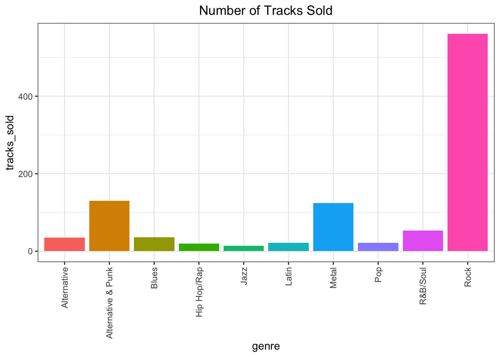

```r
result %>%
  ggplot(aes(x = genre, y = tracks_sold, fill = genre)) +
  geom_col() +
  theme_bw() +
  theme(axis.text.x = element_text(angle = 90,
                                   vjust = 0.5,
                                   hjust = 1),
        legend.position = "none",
        plot.title = element_text(hjust = 0.5)) +
  ggtitle("Number of Tracks Sold")
```

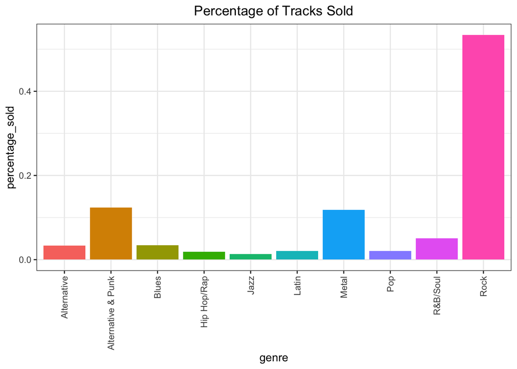

```r
result %>%
  ggplot(aes(x = genre, y = percentage_sold, fill = genre)) +
  geom_col() +
  theme_bw() +
  theme(axis.text.x = element_text(angle = 90,
                                   vjust = 0.5,
                                   hjust = 1),
        legend.position = "none",
        plot.title = element_text(hjust = 0.5)) +
  ggtitle("Percentage of Tracks Sold")
```

Rock is by far the most purchased genre in the US, by both absolute number and percentage.

### Employee Performance

Determine performance of sales support agents by analyzing purchases of customers belonging to each agent.

First, write query to pull total dollar amount of sales assigned to each sales support agent.

total dollar amount of sales assigned to each sales support agent within the company

```r
performance_query <- "
WITH customer_invoice AS
  (
  SELECT
    c.customer_id,
    c.support_rep_id,
    SUM(i.total) total_by_employee
  FROM customer c
  INNER JOIN invoice i ON i.customer_id = c.customer_id
  GROUP BY c.support_rep_id
  )

SELECT
  e.*,
  ci.total_by_employee
FROM employee e
INNER JOIN customer_invoice ci ON ci.support_rep_id = e.employee_id
ORDER BY ci.total_by_employee DESC
"

performance_result <- run_query(performance_query, db)
performance_result
```

```
##   employee_id last_name first_name               title reports_to
## 1           3   Peacock       Jane Sales Support Agent          2
## 2           4      Park   Margaret Sales Support Agent          2
## 3           5   Johnson      Steve Sales Support Agent          2
##             birthdate           hire_date          address    city state
## 1 1973-08-29 00:00:00 2017-04-01 00:00:00    1111 6 Ave SW Calgary    AB
## 2 1947-09-19 00:00:00 2017-05-03 00:00:00 683 10 Street SW Calgary    AB
## 3 1965-03-03 00:00:00 2017-10-17 00:00:00     7727B 41 Ave Calgary    AB
##   country postal_code             phone               fax
## 1  Canada     T2P 5M5 +1 (403) 262-3443 +1 (403) 262-6712
## 2  Canada     T2P 5G3 +1 (403) 263-4423 +1 (403) 263-4289
## 3  Canada     T3B 1Y7  1 (780) 836-9987  1 (780) 836-9543
##                      email total_by_employee
## 1     jane@chinookcorp.com           1731.51
## 2 margaret@chinookcorp.com           1584.00
## 3    steve@chinookcorp.com           1393.92
```

Plot the results of the query.

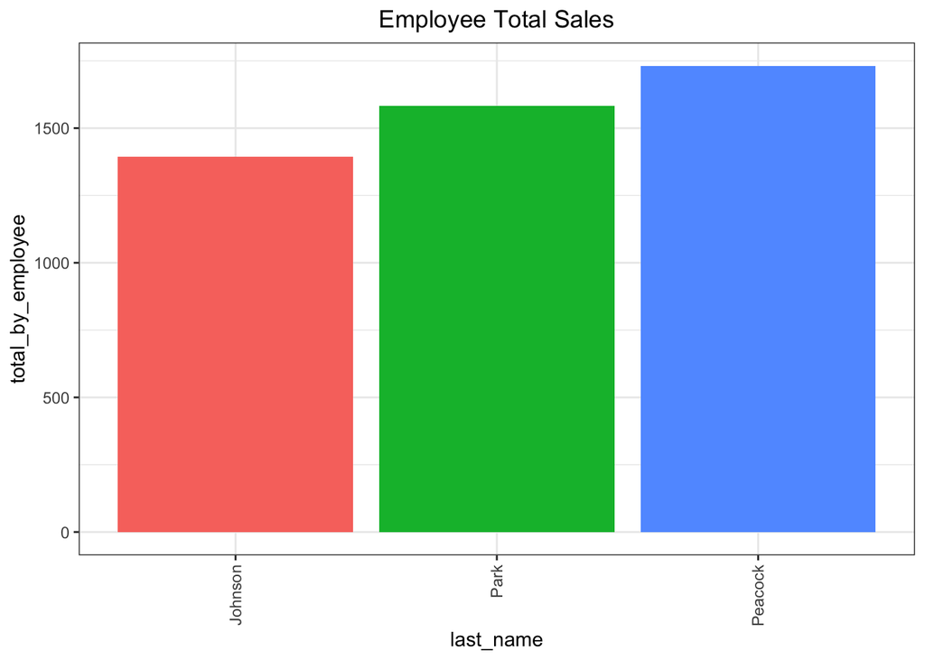

```r
performance_result %>%
  ggplot(aes(x=last_name, y=total_by_employee, fill=last_name)) +
  geom_col() +
  ggtitle("Employee Total Sales") +
  theme_bw() +
  theme(axis.text.x = element_text(angle = 90,
                                   vjust = 0.5,
                                   hjust = 1),
        legend.position = "none",
        plot.title = element_text(hjust = 0.5))
```

All employees that made the chart are based in Calgary, Canada. Jane Peacock has the most sales but also the earliest hire date.

### Sales Data by Country

Write a query that collates data on purchases from different countries. For each country, include: * total number of customers * total value of sales * average value of sales per customer * average order value

Where a country has only one customer, collect them into an “Other” group.

The results should be sorted by the total sales from highest to lowest, with the “Other” group at the very bottom.

```r
country_query <- "
WITH customer_sales AS
  (
  SELECT
    SUM(i.total) total_per_customer,
    i.customer_id,
    c.country
  FROM invoice i
  INNER JOIN customer c ON c.customer_id = i.customer_id
  GROUP BY i.customer_id
  ),

  country_sales AS
    (
    SELECT
      CASE
        WHEN (
              SELECT count(*)
              FROM customer
              WHERE country = cs.country
              ) = 1 THEN 'Other'
          ELSE cs.country
        END AS country,
      COUNT(DISTINCT i.customer_id) customers_per_county,
      SUM(i.total) total_per_country,
      AVG(cs.total_per_customer) country_avg_per_customer,
      AVG(i.total) country_avg_order_value
    FROM invoice i
    INNER JOIN customer_sales cs ON cs.customer_id = i.customer_id
    GROUP BY 1
    ORDER BY 3 DESC
    ),

  country_sort AS
    (
    SELECT
      country,
      CASE
        WHEN country = 'Other' THEN 1
        ELSE 0
      END AS sort
    FROM country_sales
    )

SELECT cou.* FROM country_sales cou
LEFT JOIN country_sort sor ON sor.country = cou.country
ORDER BY sor.sort ASC

"

country_result <- run_query(country_query, db)
country_result
```

```
##           country customers_per_county total_per_country
## 1             USA                   13           1040.49
## 2          Canada                    8            535.59
## 3          Brazil                    5            427.68
## 4          France                    5            389.07
## 5         Germany                    4            334.62
## 6  Czech Republic                    2            273.24
## 7  United Kingdom                    3            245.52
## 8        Portugal                    2            185.13
## 9           India                    2            183.15
## 10          Other                   15           1094.94
##    country_avg_per_customer country_avg_order_value
## 1                  81.30092                7.942672
## 2                  69.62566                7.047237
## 3                  87.55820                7.011148
## 4                  78.42780                7.781400
## 5                  83.90854                8.161463
## 6                 138.20400                9.108000
## 7                  83.47821                8.768571
## 8                  91.48966                6.383793
## 9                  96.40714                8.721429
## 10                 76.12898                7.448571
```

Brazil has only 5 customers compared to 13 in the US, but each customer spends more than in the US. This would be a good place to focus on growth.

### Album Purchases

We want to figure out what percentage of purchases are individual tracks vs whole albums.

First, write a query that categorizes each invoice as either an album purchase or not and generates summary statistics on number and percentage.

```r
album_query <- "
WITH whole_invoice AS
  (
  SELECT
    i.*,
    il.*,
    t.*
  FROM invoice i
  LEFT JOIN invoice_line il ON il.invoice_id = i.invoice_id
  LEFT JOIN track t ON t.track_id = il.track_id
  ),

is_album AS
  (
  SELECT
    CASE
      WHEN (
        SELECT track_id
        FROM track
        WHERE album_id = wi.album_id
        EXCEPT
        SELECT track_id
        FROM invoice_line
        WHERE invoice_line_id = wi.invoice_line_id
      ) IS NULL
      AND (
        SELECT track_id
        FROM invoice_line
        WHERE invoice_line_id = wi.invoice_line_id
        EXCEPT
        SELECT track_id
        FROM track
        WHERE album_id = wi.album_id
      ) IS NULL
      THEN 1
      ELSE 0
    END AS is_album,
    wi.invoice_id
  FROM whole_invoice wi
  )

SELECT
  SUM(ia.is_album) number_albums_perchased,
  COUNT(DISTINCT i.invoice_id) - SUM(ia.is_album) number_nonalbums_purchased,
  (SUM(ia.is_album) / CAST(COUNT(DISTINCT i.invoice_id) AS FLOAT)) *100 percent_albums_purchased,
  ((COUNT(DISTINCT i.invoice_id) - SUM(ia.is_album)) / CAST(COUNT(DISTINCT i.invoice_id) AS FLOAT)) * 100 percent_nonalbums_purchased
FROM invoice i
LEFT JOIN is_album ia ON ia.invoice_id = i.invoice_id
"
album_result <- run_query(album_query, db)
album_result
```

```
##   number_albums_perchased number_nonalbums_purchased percent_albums_purchased
## 1                      98                        516                 15.96091
##   percent_nonalbums_purchased
## 1                    84.03909
```

Almost 16% of sales are album purchases. Therefore, it does not make sense to remove albums from the platform.